# Prinicipal Components Analysis (PCA)

Ajna Kertesz, Maddie Pickett

2022-05-10

## Goals of the project (probably should delete after finalizaing)

[1] provides background on the statistical method/topic/data visualization procedure that you have chosen to explore –> DONE [2] takes a user through one or more examples of the application of the approach with a real dataset. –> DONE

create and call at least 2 functions with documentation!! –> we have one for sd, but need another custom r package –> NOT DONE one or more datasets–> DONE

WHY IS THIS USEFUL? WHAT KIND OF DATA IS IT USED WITH? –> NOT DONE

## Introduction

Principal component analysis is a dimensionality-reduction method, that is used with multi-dimensional data sets, by transforming the variables into smaller components, without eliminating much of the data. Even though some of the accuracy may be compromised, PCA is great for simplifying very complicated and large data sets and exploring overall patterns as well as preparing the dataset for data visualization.

Generally PCA in R

The process of PCA can be broken down to 5 steps

## Step 1: Standardizing all variables

Whenever working with different data types (e.g., different measurements, units, scales, percentages…etc.) it is crucial to standardize the variables before conducting any further analysis, so any variances are measured on the same scale.

Statistically speaking this means z-scoring all the variables.

When working in R we can use the scale() function to standardize our variables. In the prcomp() functions we will take care of this by scale=TRUE and the princomp() function will take care of this when cor=TRUE. The princomp() and prcomp() represent two different methods of doing PCA. The two methods are 1. Spectral decomposition which explores the covariances / correlations between variables (prcomp()) & 2. Singular value decomposition which looks at the covariances / correlations between individuals or individual samples as a whole (princomp())

In this overview we will cover two data sets for PCA analysis. For one we will use 1. spectral decomposition and for the other we will use 2. single value decomposition.

We can go ahead and load in the needed packages and datasets for this analysis. One package you might not be familiar with is the caret package, which has the findcorrelation() function. This function allows us to remove highly correlated predictors.

```r
knitr::opts_chunk$set(echo = TRUE)

library(tidyverse)
library(dplyr)
library(caret)
library(corrplot)
library(readr)

f<-"https://raw.githubusercontent.com/mrpickett26/Final_Group_Project/main/WBCDSdata.csv"
wdbc<- read_csv(f, col_names=TRUE) ## load in the Wisconsin breast cancer dataset
wbg <- read.csv2("https://userpage.fu-berlin.de/soga/300/30100_data_sets/DWD.csv", stringsAsFactors = FALSE)
```

Now we should make the data into a tidier format where we can use it more easily, we also want to clean it up– in the weather dataset we can exclude some features before we even begin analysis to make it a little more straightforward. In this case we are looking at how the variables interact with each other regardless of ID number, so we can drop any ID variables.

```r
wbg<- wbg%>%select(LAT, LON, ALTITUDE, RECORD.LENGTH, MEAN.ANNUAL.AIR.TEMP, MEAN.MONTHLY.MAX.TEMP, MEAN.MONTHLY.MIN.TEMP, MEAN.ANNUAL.RAINFALL, MEAN.ANNUAL.SUNSHINE, MEAN.ANNUAL.WIND.SPEED,MEAN.RANGE.AIR.TEMP, MEAN.CLOUD.COVER, MAX.RAINFALL)

str(wbg)
```

```
## 'data.frame':    599 obs. of  13 variables:
##  $ LAT                   : num  47.8 50.8 52.9 48.2 48.6 ...
##  $ LON                   : num  8.85 6.09 8.24 8.98 13.05 ...
##  $ ALTITUDE              : num  478 202 44 759 340 65 300 780 213 750 ...
##  $ RECORD.LENGTH         : int  55 160 45 30 64 55 38 67 67 33 ...
##  $ MEAN.ANNUAL.AIR.TEMP  : num  8.2 9.8 9.2 7.4 8.4 9.3 8.2 5.1 8.4 5.7 ...
##  $ MEAN.MONTHLY.MAX.TEMP : num  13.1 13.6 13.2 12.2 13.4 13.4 12.7 8.9 12.9 9.2 ...
##  $ MEAN.MONTHLY.MIN.TEMP : num  3.5 6.3 5.4 3.3 3.9 5.2 4.1 2.2 4.2 2.7 ...
##  $ MEAN.ANNUAL.RAINFALL  : num  755 820 759 919 790 794 657 NA NA 915 ...
##  $ MEAN.ANNUAL.SUNSHINE  : num  NA 1531 1459 1725 1595 ...
##  $ MEAN.ANNUAL.WIND.SPEED: num  2 3 2 2 1 2 3 3 2 3 ...
##  $ MEAN.RANGE.AIR.TEMP   : num  9.6 7.3 7.8 8.9 9.5 8.2 8.6 6.7 8.6 6.5 ...
##  $ MEAN.CLOUD.COVER      : num  67 67 67 66 65 67 72 72 66 64 ...
##  $ MAX.RAINFALL          : num  39 36 32 43 43 33 37 NA NA 40 ...
```

```r
wbg<-na.omit(wbg)
```

The WBC data set has tumors classified as benign and malignant, it is useful to go ahead and break down the dataset into those two subgroups [Benign and Malignant] and subset them by response variable.

```r
wdbc.data <- as.matrix(wdbc[,c(3:32)])
row.names(wdbc.data) <- wdbc$id
diagnosis <- as.numeric(wdbc$diagnosis == "Malignant") #Creates a new diagnosis vector
outcome<- wdbc$diagnosis

round(colMeans(wdbc.data),2) #It is also helpful to know the mean of the columns. This finds the means of each variable in the matrix.
```

```
##             radius_mean            texture_mean          perimeter_mean
##                   14.14                   19.28                   92.05
##               area_mean         smoothness_mean        compactness_mean
##                  655.72                    0.10                    0.10
##          concavity_mean     concave points_mean           symmetry_mean
##                    0.09                    0.05                    0.18
##  fractal_dimension_mean               radius_se              texture_se
##                    0.06                    0.41                    1.22
##            perimeter_se                 area_se           smoothness_se
##                    2.87                   40.37                    0.01
##          compactness_se            concavity_se       concave points_se
##                    0.03                    0.03                    0.01
##             symmetry_se    fractal_dimension_se            radius_worst
##                    0.02                    0.00                   16.28
##           texture_worst         perimeter_worst              area_worst
##                   25.67                  107.35                  881.66
##        smoothness_worst       compactness_worst         concavity_worst
##                    0.13                    0.25                    0.27
##    concave points_worst          symmetry_worst fractal_dimension_worst
##                    0.11                    0.29                    0.08
```

```r
# Also helpful to know the standard deviations of each variable in building the PCA model
SD_var <- function(x){
    round(sd(x), 2)
}
apply(wdbc.data, 2, SD_var)
```

```
##             radius_mean            texture_mean          perimeter_mean
##                    3.52                    4.30                   24.25
##               area_mean         smoothness_mean        compactness_mean
##                  351.66                    0.01                    0.05
##          concavity_mean     concave points_mean           symmetry_mean
##                    0.08                    0.04                    0.03
##  fractal_dimension_mean               radius_se              texture_se
##                    0.01                    0.28                    0.55
##            perimeter_se                 area_se           smoothness_se
##                    2.02                   45.52                    0.00
##          compactness_se            concavity_se       concave points_se
##                    0.02                    0.03                    0.01
##             symmetry_se    fractal_dimension_se            radius_worst
##                    0.01                    0.00                    4.83
##           texture_worst         perimeter_worst              area_worst
##                    6.15                   33.57                  569.28
##        smoothness_worst       compactness_worst         concavity_worst
##                    0.02                    0.16                    0.21
##    concave points_worst          symmetry_worst fractal_dimension_worst
##                    0.07                    0.06                    0.02
```

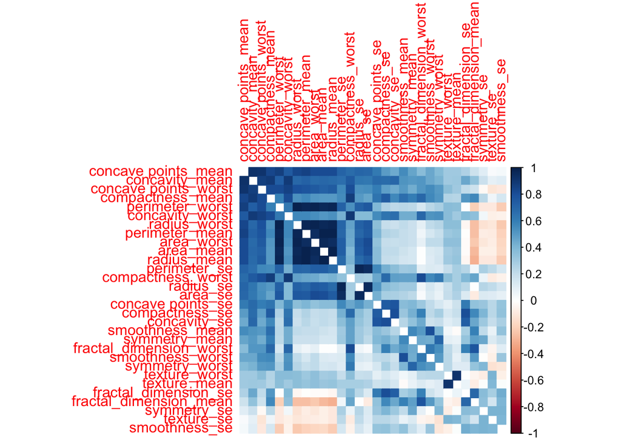

```r
corMatrix <- wdbc[,c(3:32)]

#This function creates a correlation matrix. A correlation matrix is a table that demonstrates which variables have a linear relationship between them.
M <- round(cor(corMatrix), 2)

#Allows for visualization of the correlation matrix in a correlation plot.
corrplot(M, diag = FALSE, method="color", order="FPC", tl.srt = 90)
```

```r
#This plot shows us that there are many variables that are correlated to one another
```

## Step 2: Creating a covariance Matrix

Next, we need to understand how each variable is different from the mean and see if there are any associations. To do this, we will need to create a covariance matrix, which is a p x p symmetric matrix (where p is the number of dimensions) that includes all the variables (covariates) and the initial variables.

Statistically it looks something like this.

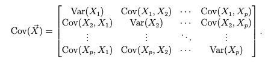

We can create this covariance matrix by following these steps:

1. Spectral decomposition

```r
wbg.pcov <- prcomp(wbg, cor=FALSE, scores=TRUE) #error with infinate or missing values
summary(wbg.pcov) #Build the covariance matrix
```

```
## Importance of components:
##                            PC1      PC2      PC3      PC4     PC5     PC6
## Standard deviation     336.239 205.0131 133.5572 38.98558 3.76351 2.87229
## Proportion of Variance   0.648   0.2409   0.1022  0.00871 0.00008 0.00005
## Cumulative Proportion    0.648   0.8889   0.9911  0.99983 0.99991 0.99995
##                            PC7     PC8    PC9   PC10   PC11   PC12    PC13
## Standard deviation     2.15926 1.46936 0.8693 0.4508 0.3815 0.1251 0.05269
## Proportion of Variance 0.00003 0.00001 0.0000 0.0000 0.0000 0.0000 0.00000
## Cumulative Proportion  0.99998 0.99999 1.0000 1.0000 1.0000 1.0000 1.00000
```

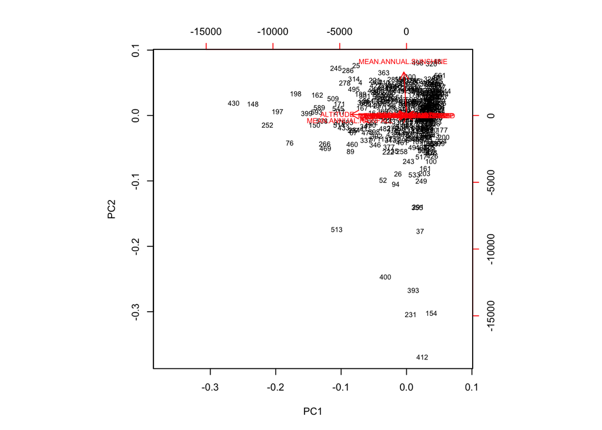

```r
cex.before <- par("cex")
par(cex = 0.7)
biplot(wbg.pcov) #Create a biplot of the covariance
```

```r
str(wbg)
```

```
## 'data.frame':    397 obs. of  13 variables:
##  $ LAT                   : num  50.8 52.9 48.2 48.6 49.7 ...
##  $ LON                   : num  6.09 8.24 8.98 13.05 8.12 ...
##  $ ALTITUDE              : num  202 44 759 340 215 383 54 9 630 413 ...
##  $ RECORD.LENGTH         : int  160 45 30 64 115 103 108 77 85 95 ...
##  $ MEAN.ANNUAL.AIR.TEMP  : num  9.8 9.2 7.4 8.4 9.5 7.9 8.4 8.1 6.4 7.5 ...
##  $ MEAN.MONTHLY.MAX.TEMP : num  13.6 13.2 12.2 13.4 13.8 12.5 12.9 13.1 10.6 12.2 ...
##  $ MEAN.MONTHLY.MIN.TEMP : num  6.3 5.4 3.3 3.9 5.3 3.6 4.3 5.1 2.9 3.3 ...
##  $ MEAN.ANNUAL.RAINFALL  : num  820 759 919 790 526 690 531 553 902 681 ...
##  $ MEAN.ANNUAL.SUNSHINE  : num  1531 1459 1725 1595 1597 ...
##  $ MEAN.ANNUAL.WIND.SPEED: num  3 2 2 1 2 1 2 3 3 2 ...
##  $ MEAN.RANGE.AIR.TEMP   : num  7.3 7.8 8.9 9.5 8.6 9.2 8.5 8 7.8 9 ...
##  $ MEAN.CLOUD.COVER      : num  67 67 66 65 65 66 68 62 66 65 ...
##  $ MAX.RAINFALL          : num  36 32 43 43 31 36 37 32 46 36 ...
##  - attr(*, "na.action")= 'omit' Named int  1 6 7 8 9 10 11 19 21 22 ...
##   ..- attr(*, "names")= chr  "1" "6" "7" "8" ...
```

2. Singular value decomposition

```r
wdbc.pcov <- princomp(wdbc.data, scores = TRUE)
summary(wdbc.pcov) #Build the covariance matrix
```

```
## Importance of components:
##                             Comp.1     Comp.2       Comp.3       Comp.4
## Standard deviation     665.3817048 85.4178639 26.510816702 7.3917203656
## Proportion of Variance   0.9820363  0.0161839  0.001558949 0.0001211928
## Cumulative Proportion    0.9820363  0.9982202  0.999779136 0.9999003291
##                              Comp.5       Comp.6       Comp.7       Comp.8
## Standard deviation     6.285379e+00 1.723376e+00 1.341902e+00 6.094794e-01
## Proportion of Variance 8.762919e-05 6.587882e-06 3.994177e-06 8.239556e-07
## Cumulative Proportion  9.999880e-01 9.999945e-01 9.999985e-01 9.999994e-01
##                              Comp.9      Comp.10      Comp.11      Comp.12
## Standard deviation     3.939371e-01 2.896455e-01 1.776972e-01 8.644681e-02
## Proportion of Variance 3.442227e-07 1.860884e-07 7.004017e-08 1.657615e-08
## Cumulative Proportion  9.999997e-01 9.999999e-01 1.000000e+00 1.000000e+00
##                             Comp.13      Comp.14      Comp.15      Comp.16
## Standard deviation     5.622228e-02 4.648825e-02 3.642125e-02 2.526125e-02
## Proportion of Variance 7.011366e-09 4.793715e-09 2.942358e-09 1.415453e-09
## Cumulative Proportion  1.000000e+00 1.000000e+00 1.000000e+00 1.000000e+00
##                             Comp.17      Comp.18      Comp.19      Comp.20
## Standard deviation     1.935774e-02 1.528887e-02 1.357492e-02 1.271995e-02
## Proportion of Variance 8.311803e-10 5.184857e-10 4.087525e-10 3.588860e-10
## Cumulative Proportion  1.000000e+00 1.000000e+00 1.000000e+00 1.000000e+00
##                             Comp.21      Comp.22      Comp.23      Comp.24
## Standard deviation     8.801581e-03 7.579317e-03 5.909075e-03 5.305210e-03
## Proportion of Variance 1.718332e-10 1.274224e-10 7.745061e-11 6.242966e-11
## Cumulative Proportion  1.000000e+00 1.000000e+00 1.000000e+00 1.000000e+00
##                             Comp.25      Comp.26      Comp.27      Comp.28
## Standard deviation     3.978787e-03 3.530384e-03 1.917828e-03 1.675896e-03
## Proportion of Variance 3.511456e-11 2.764583e-11 8.158399e-12 6.229881e-12
## Cumulative Proportion  1.000000e+00 1.000000e+00 1.000000e+00 1.000000e+00
##                             Comp.29      Comp.30
## Standard deviation     1.415907e-03 8.352584e-04
## Proportion of Variance 4.446880e-12 1.547489e-12
## Cumulative Proportion  1.000000e+00 1.000000e+00
```

[output not shown]

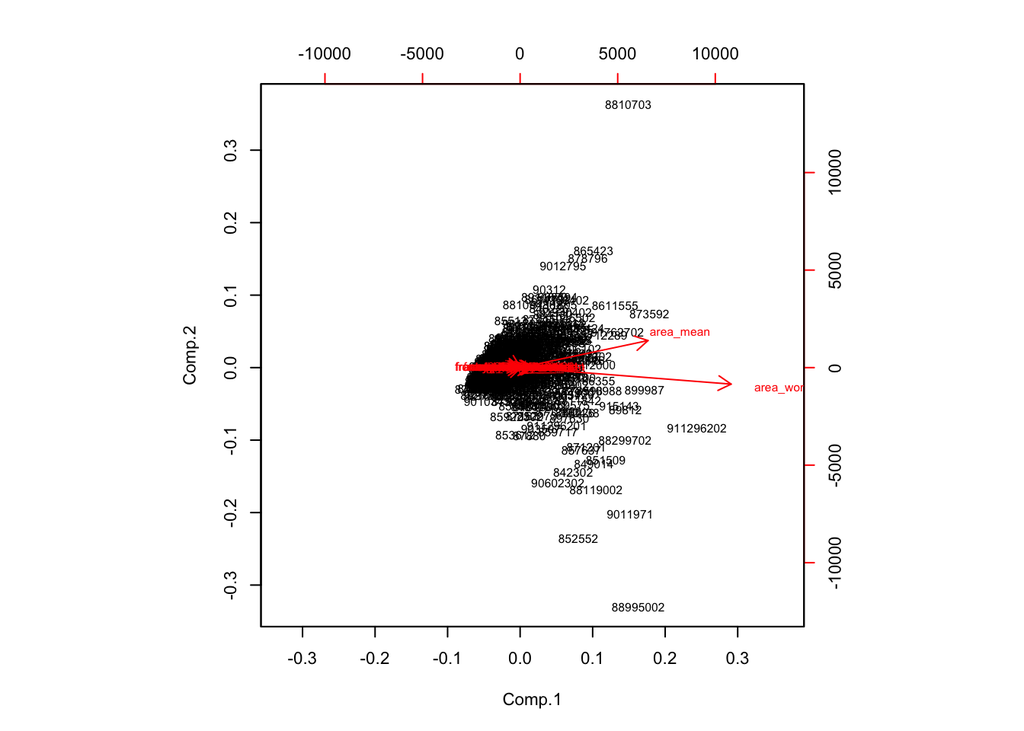

```r
cex.before <- par("cex")
par(cex = 0.7)
biplot(wdbc.pcov) #Create a biplot of the covariance
```

When working in R, we can also use the cov() function to create the covariate matrix

```r
cov(wbg)
```

```
##                                 LAT          LON     ALTITUDE RECORD.LENGTH
## LAT                       3.9083311   0.31471758  -363.947574  1.114915e+00
## LON                       0.3147176   4.50335838    65.730720 -4.628255e-01
## ALTITUDE               -363.9475739  65.73071985 74843.841844 -6.789435e+02
## RECORD.LENGTH             1.1149147  -0.46282546  -678.943535  1.552087e+03
## MEAN.ANNUAL.AIR.TEMP      0.4051971  -0.84511327  -270.394549  1.246641e+00
## MEAN.MONTHLY.MAX.TEMP    -0.2918183  -0.63208114  -253.862668  1.823202e+00
## MEAN.MONTHLY.MIN.TEMP     0.8519915  -0.94548367  -253.174712  2.080328e+00
## MEAN.ANNUAL.RAINFALL   -203.0942769 -67.18623567 46507.369717 -1.163307e+03
## MEAN.ANNUAL.SUNSHINE    -31.8965038  53.50339561  3384.126415  4.527111e+02
## MEAN.ANNUAL.WIND.SPEED    0.6192575   0.08356332     1.499841  9.750910e-01
## MEAN.RANGE.AIR.TEMP      -1.1398222   0.31438218    -1.544904 -8.724906e-02
## MEAN.CLOUD.COVER          0.7452552  -0.52549989   108.449374  2.027231e+00
## MAX.RAINFALL             -8.5491138   2.50954407  1588.926450 -3.224174e+01
##                        MEAN.ANNUAL.AIR.TEMP MEAN.MONTHLY.MAX.TEMP
## LAT                               0.4051971            -0.2918183
## LON                              -0.8451133            -0.6320811
## ALTITUDE                       -270.3945494          -253.8626682
## RECORD.LENGTH                     1.2466408             1.8232018
## MEAN.ANNUAL.AIR.TEMP              1.5566522             1.6484184
## MEAN.MONTHLY.MAX.TEMP             1.6484184             2.1207512
## MEAN.MONTHLY.MIN.TEMP             1.3473533             1.1495423
## MEAN.ANNUAL.RAINFALL           -173.2623966          -174.1976859
## MEAN.ANNUAL.SUNSHINE             -5.4415859            -4.4152202
## MEAN.ANNUAL.WIND.SPEED           -0.2054398            -0.5114183
## MEAN.RANGE.AIR.TEMP               0.3040843             0.9678963
## MEAN.CLOUD.COVER                 -1.0099019            -1.4644658
## MAX.RAINFALL                     -5.4527988            -4.7877357
##                        MEAN.MONTHLY.MIN.TEMP MEAN.ANNUAL.RAINFALL
## LAT                               0.85199154         -203.0942769
## LON                              -0.94548367          -67.1862357
## ALTITUDE                       -253.17471249        46507.3697173
## RECORD.LENGTH                     2.08032847        -1163.3068722
## MEAN.ANNUAL.AIR.TEMP              1.34735332         -173.2623966
## MEAN.MONTHLY.MAX.TEMP             1.14954234         -174.1976859
## MEAN.MONTHLY.MIN.TEMP             1.46154721         -146.2282752
## MEAN.ANNUAL.RAINFALL           -146.22827520        56043.4069282
## MEAN.ANNUAL.SUNSHINE              6.21647139          132.2893354
## MEAN.ANNUAL.WIND.SPEED            0.06225097            0.4430323
## MEAN.RANGE.AIR.TEMP              -0.30549443          -28.5086495
```

[output cut: 15 more lines]

```
## MAX.RAINFALL                     120.852556            -0.34851665
##                        MEAN.RANGE.AIR.TEMP MEAN.CLOUD.COVER MAX.RAINFALL
## LAT                            -1.13982216        0.7452552   -8.5491138
## LON                             0.31438218       -0.5254999    2.5095441
## ALTITUDE                       -1.54490433      108.4493741 1588.9264496
## RECORD.LENGTH                  -0.08724906        2.0272307  -32.2417373
## MEAN.ANNUAL.AIR.TEMP            0.30408429       -1.0099019   -5.4527988
## MEAN.MONTHLY.MAX.TEMP           0.96789634       -1.4644658   -4.7877357
## MEAN.MONTHLY.MIN.TEMP          -0.30549443       -0.6699317   -5.0951950
## MEAN.ANNUAL.RAINFALL          -28.50864947       84.7735733 1574.6057616
## MEAN.ANNUAL.SUNSHINE          -10.56663868     -129.9141096  120.8525558
## MEAN.ANNUAL.WIND.SPEED         -0.57305104        0.4360990   -0.3485167
## MEAN.RANGE.AIR.TEMP             1.27212528       -0.7816299    0.3069282
## MEAN.CLOUD.COVER               -0.78162990        8.8445666    0.6550263
## MAX.RAINFALL                    0.30692822        0.6550263   58.5403404
```

```r
cov(wdbc.data)
```

```
##                           radius_mean  texture_mean perimeter_mean
## radius_mean              1.236919e+01  4.975301e+00   8.510231e+01
## texture_mean             4.975301e+00  1.848283e+01   3.490911e+01
## perimeter_mean           8.510231e+01  3.490911e+01   5.880537e+02
## area_mean                1.221312e+03  4.912468e+02   8.413770e+03
## smoothness_mean          7.977424e-03 -1.011624e-03   6.755770e-02
## compactness_mean         9.368010e-02  5.442489e-02   7.112491e-01
## concavity_mean           1.894640e-01  1.046989e-01   1.382769e+00
## concave points_mean      1.121232e-01  4.951709e-02   7.999684e-01
## symmetry_mean            1.404566e-02  8.642084e-03   1.203885e-01
## fractal_dimension_mean  -7.811903e-03 -2.288540e-03  -4.524600e-02
## radius_se                6.646017e-01  3.297983e-01   4.668107e+00
## texture_se              -1.871470e-01  9.163532e-01  -1.148607e+00
## perimeter_se             4.808444e+00  2.456719e+00   3.408833e+01
## area_se                  1.179379e+02  5.112707e+01   8.232962e+02
## smoothness_se           -2.357825e-03  8.418747e-05  -1.480274e-02
## compactness_se           1.278925e-02  1.500579e-02   1.076835e-01
## concavity_se             2.033647e-02  1.893259e-02   1.651092e-01
## concave points_se        8.061288e-03  4.465472e-03   6.024435e-02
## symmetry_se             -2.974395e-03  2.674027e-04  -1.594145e-02
## fractal_dimension_se    -4.097096e-04  6.302523e-04  -4.345139e-04
## radius_worst             1.646623e+01  7.405394e+00   1.135286e+02
## texture_worst            6.497238e+00  2.410914e+01   4.570315e+01
## perimeter_worst          1.139490e+02  5.228339e+01   7.899822e+02
## area_worst               1.884673e+03  8.484444e+02   1.300149e+04
## smoothness_worst         9.164522e-03  8.017883e-03   8.037240e-02
## compactness_worst        2.275181e-01  1.901025e-01   1.730778e+00
## concavity_worst          3.850077e-01  2.731113e-01   2.842364e+00
## concave points_worst     1.714075e-01  8.470121e-02   1.225101e+00
## symmetry_worst           3.577533e-02  2.801888e-02   2.845696e-01
## fractal_dimension_worst  2.980312e-04  9.402207e-03   2.137503e-02
##                             area_mean smoothness_mean compactness_mean
## radius_mean              1.221312e+03    7.977424e-03     9.368010e-02
## texture_mean             4.912468e+02   -1.011624e-03     5.442489e-02
## perimeter_mean           8.413770e+03    6.755770e-02     7.112491e-01
## area_mean                1.236652e+05    8.411100e-01     9.230432e+00
## smoothness_mean          8.411100e-01    1.947699e-04     4.857460e-04
## compactness_mean         9.230432e+00    4.857460e-04     2.787592e-03
## concavity_mean           1.920452e+01    5.794142e-04     3.715166e-03
## concave points_mean      1.122083e+01    2.989204e-04     1.700989e-03
```

[output cut: 255 more lines]

```
## compactness_se            3.083044e-04            1.909854e-04
## concavity_se              3.698595e-04            2.391802e-04
## concave points_se         5.466730e-05            3.439887e-05
## symmetry_se               1.995319e-04            1.182683e-05
## fractal_dimension_se      1.821347e-05            2.828600e-05
## radius_worst              7.291282e-02            8.012550e-03
## texture_worst             8.879043e-02            2.447990e-02
## perimeter_worst           5.609849e-01            8.333025e-02
## area_worst                7.376858e+00            8.058225e-01
## smoothness_worst          6.985958e-04            2.541310e-04
## compactness_worst         5.990521e-03            2.302582e-03
## concavity_worst           6.883953e-03            2.584829e-03
## concave points_worst      2.046631e-03            6.051249e-04
## symmetry_worst            3.834318e-03            6.019829e-04
## fractal_dimension_worst   6.019829e-04            3.264600e-04
```

## Step 3: Computing the eigenvectors and eigenvalues

Eigenvectors and eigenvalues are linear transformations of a nonzero vector that allow us to determine the *principal components* of the data.

Therefore, this new way of organizing the data will allow us to reduce complexity (dimensionality) without loosing much information.

Computationally, this looks like this:

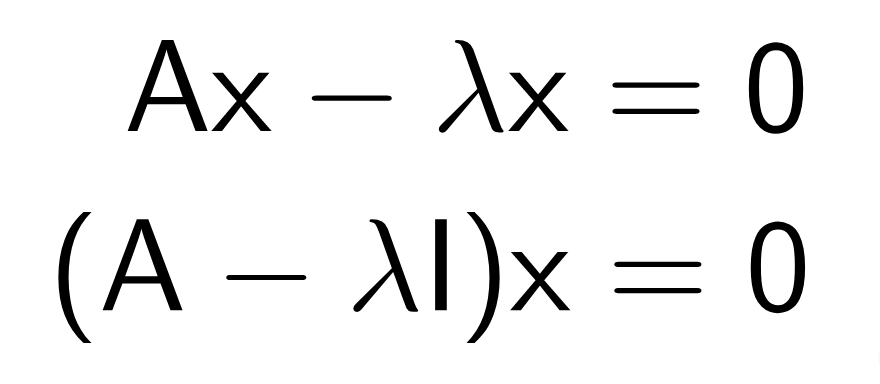

After creating the biplots in the previos step, we can see that area_worst and area_mean have much larger covariances than the other variables included. This is due to a scale issue and therefore indicates to us that we need to scale those variables for future PCA analysis. Let’s calculate the eigenvectors and eigenvalues in the following steps.

```r
par(cex = cex.before)
par(mfrow = c(1, 2)) #Set up a grid for PCA analysis
pr.cvar <- wbg.pcov$sdev ^ 2 #Calculate variability of each variable
pve_cov_wbg <- pr.cvar/sum(pr.cvar) #Calculate the variance as explained by each principle component

# We now need to calculate the eigen values and percent variance of each variable or "component"
round(pr.cvar, 2) #Eigen Values
```

```
##  [1] 113056.40  42030.38  17837.52   1519.88     14.16      8.25      4.66
##  [8]      2.16      0.76      0.20      0.15      0.02      0.00
```

```r
round(pve_cov_wbg, 2) # Percent Variance
```

```
##  [1] 0.65 0.24 0.10 0.01 0.00 0.00 0.00 0.00 0.00 0.00 0.00 0.00 0.00
```

```r
#use the prcomp() function to calculate the eigenvectors
wbg.pr <- prcomp(wbg, scale = TRUE, center = TRUE)
summary(wbg.pr)
```

```
## Importance of components:
##                           PC1    PC2    PC3     PC4     PC5     PC6     PC7
## Standard deviation     2.1711 1.6378 1.1716 1.10492 1.00608 0.83074 0.71444
## Proportion of Variance 0.3626 0.2063 0.1056 0.09391 0.07786 0.05309 0.03926
## Cumulative Proportion  0.3626 0.5689 0.6745 0.76842 0.84629 0.89937 0.93864
##                            PC8     PC9    PC10    PC11    PC12    PC13
## Standard deviation     0.65762 0.52192 0.24515 0.14647 0.09785 0.04161
## Proportion of Variance 0.03327 0.02095 0.00462 0.00165 0.00074 0.00013
## Cumulative Proportion  0.97190 0.99286 0.99748 0.99913 0.99987 1.00000
```

```r
######wdbc

par(cex = cex.before)
par(mfrow = c(1, 2)) #Set up a grid for PCA analysis
pr.cvar <- wdbc.pcov$sdev ^ 2 #Calculate variability of each variable
pve_cov <- pr.cvar/sum(pr.cvar) #Calculate the variance as explained by each principle component

# We now need to calculate the eigen values and percent variance of each variable or "component"
round(pr.cvar, 2) #Eigen Values
```

```
##    Comp.1    Comp.2    Comp.3    Comp.4    Comp.5    Comp.6    Comp.7    Comp.8
## 442732.81   7296.21    702.82     54.64     39.51      2.97      1.80      0.37
##    Comp.9   Comp.10   Comp.11   Comp.12   Comp.13   Comp.14   Comp.15   Comp.16
##      0.16      0.08      0.03      0.01      0.00      0.00      0.00      0.00
##   Comp.17   Comp.18   Comp.19   Comp.20   Comp.21   Comp.22   Comp.23   Comp.24
##      0.00      0.00      0.00      0.00      0.00      0.00      0.00      0.00
##   Comp.25   Comp.26   Comp.27   Comp.28   Comp.29   Comp.30
##      0.00      0.00      0.00      0.00      0.00      0.00
```

```r
round(pve_cov, 2) # Percent Variance
```

```
##  Comp.1  Comp.2  Comp.3  Comp.4  Comp.5  Comp.6  Comp.7  Comp.8  Comp.9 Comp.10
##    0.98    0.02    0.00    0.00    0.00    0.00    0.00    0.00    0.00    0.00
## Comp.11 Comp.12 Comp.13 Comp.14 Comp.15 Comp.16 Comp.17 Comp.18 Comp.19 Comp.20
##    0.00    0.00    0.00    0.00    0.00    0.00    0.00    0.00    0.00    0.00
## Comp.21 Comp.22 Comp.23 Comp.24 Comp.25 Comp.26 Comp.27 Comp.28 Comp.29 Comp.30
##    0.00    0.00    0.00    0.00    0.00    0.00    0.00    0.00    0.00    0.00
```

```r
#use the prcomp() function to calculate the eigenvectors
wdbc.pr <- prcomp(wdbc.data, scale = TRUE, center = TRUE)
summary(wdbc.pr)
```

```
## Importance of components:
##                           PC1    PC2     PC3     PC4     PC5    PC6     PC7
## Standard deviation     3.6430 2.3887 1.67894 1.40544 1.28662 1.0982 0.81949
## Proportion of Variance 0.4424 0.1902 0.09396 0.06584 0.05518 0.0402 0.02239
## Cumulative Proportion  0.4424 0.6326 0.72653 0.79237 0.84755 0.8878 0.91013
##                            PC8     PC9    PC10    PC11    PC12    PC13    PC14
## Standard deviation     0.68973 0.64618 0.59266 0.54282 0.51175 0.49126 0.39418
## Proportion of Variance 0.01586 0.01392 0.01171 0.00982 0.00873 0.00804 0.00518
## Cumulative Proportion  0.92599 0.93991 0.95162 0.96144 0.97017 0.97821 0.98339
##                           PC15    PC16    PC17    PC18    PC19    PC20   PC21
## Standard deviation     0.30696 0.28022 0.24367 0.22980 0.22256 0.17656 0.1729
## Proportion of Variance 0.00314 0.00262 0.00198 0.00176 0.00165 0.00104 0.0010
## Cumulative Proportion  0.98653 0.98915 0.99113 0.99289 0.99454 0.99558 0.9966
##                           PC22    PC23   PC24    PC25    PC26    PC27    PC28
## Standard deviation     0.16547 0.15629 0.1344 0.12458 0.08929 0.08295 0.03993
## Proportion of Variance 0.00091 0.00081 0.0006 0.00052 0.00027 0.00023 0.00005
## Cumulative Proportion  0.99749 0.99830 0.9989 0.99942 0.99969 0.99992 0.99997
##                           PC29    PC30
## Standard deviation     0.02728 0.01153
## Proportion of Variance 0.00002 0.00000
## Cumulative Proportion  1.00000 1.00000
```

## Step 4: Selecting the feature vector - Feture vector extraction

We can now use these metrics to calculate the cumulative percentages. Cumulative percentage is another way of expressing frequency distribution. It calculates the percentage of the cumulative frequency within each interval, much as relative frequency distribution calculates the percentage of frequency. The main advantage of cumulative percentage over cumulative frequency as a measure of frequency distribution is that it provides an easier way to compare different sets of data.Cumulative percentage is calculated by dividing the cumulative frequency by the total number of observations (n), then multiplying it by 100 (the last value will always be equal to 100%).

It is useful in PCA to create a scree plot of covariance and cumulative proportion of variance explained. In multivariate statistics, a scree plot is a line plot of the eigenvalues of factors or principal components in an analysis. The scree plot is used to determine the number of factors to retain in an exploratory factor analysis (FA) or principal components to keep in a principal component analysis (PCA).

```r
round(cumsum(pve_cov_wbg), 2) #Cumulative percentage
```

```
##  [1] 0.65 0.89 0.99 1.00 1.00 1.00 1.00 1.00 1.00 1.00 1.00 1.00 1.00
```

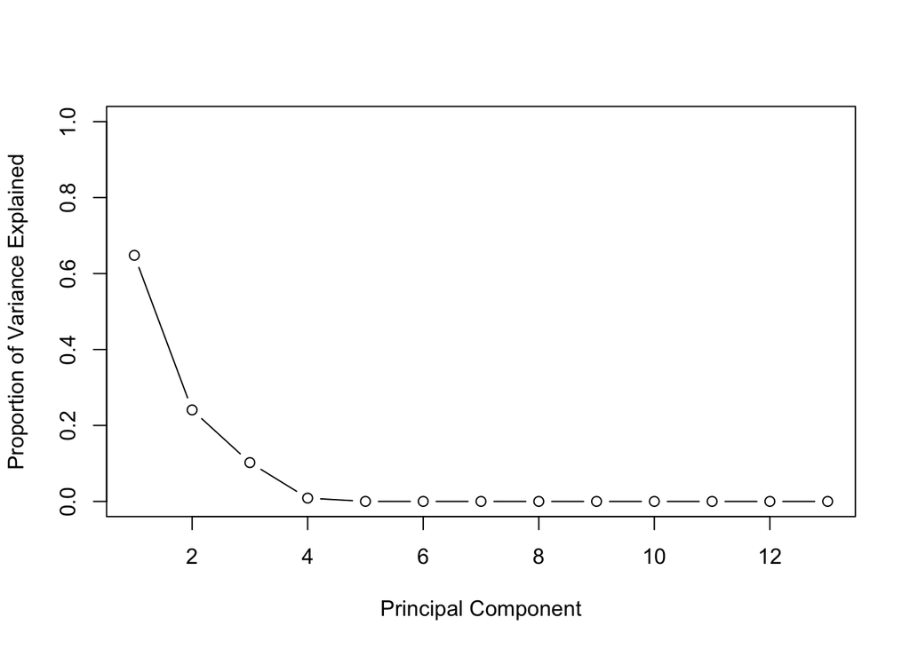

```r
# Plot variance explained for each principal component
plot(pve_cov_wbg, xlab = "Principal Component",
     ylab = "Proportion of Variance Explained",
     ylim = c(0, 1), type = "b")
```

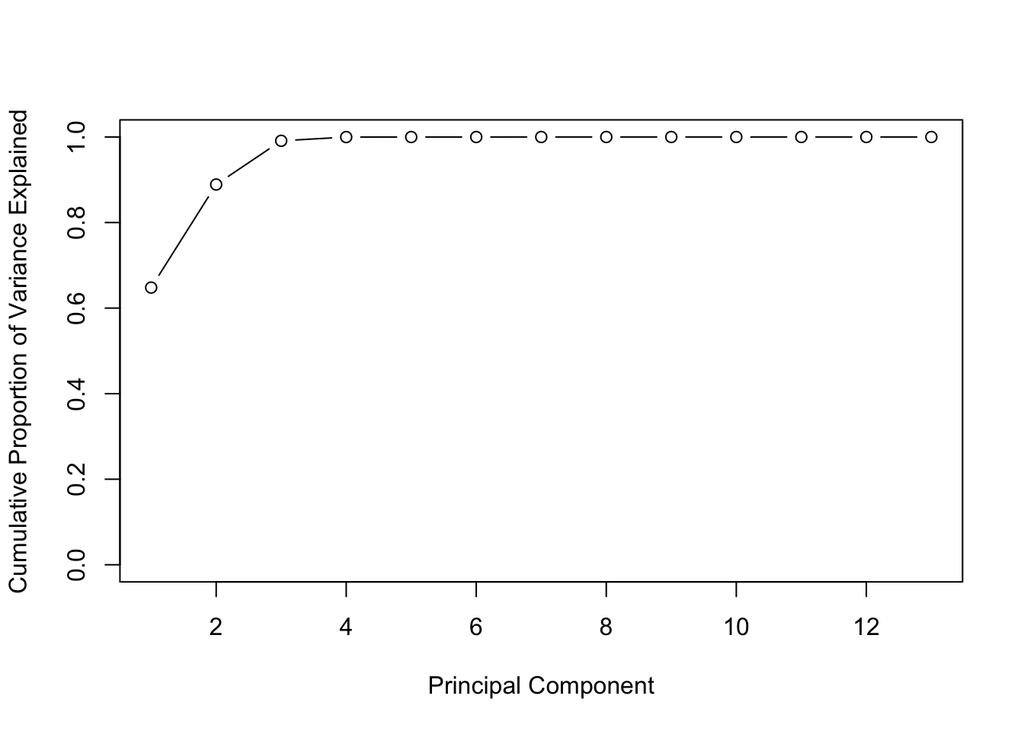

```r
# Plot cumulative proportion of variance explained
plot(cumsum(pve_cov_wbg), xlab = "Principal Component",
     ylab = "Cumulative Proportion of Variance Explained",
     ylim = c(0, 1), type = "b")
```

```r
#######

round(cumsum(pve_cov), 2) #Cumulative percentage
```

```
##  Comp.1  Comp.2  Comp.3  Comp.4  Comp.5  Comp.6  Comp.7  Comp.8  Comp.9 Comp.10
##    0.98    1.00    1.00    1.00    1.00    1.00    1.00    1.00    1.00    1.00
## Comp.11 Comp.12 Comp.13 Comp.14 Comp.15 Comp.16 Comp.17 Comp.18 Comp.19 Comp.20
##    1.00    1.00    1.00    1.00    1.00    1.00    1.00    1.00    1.00    1.00
## Comp.21 Comp.22 Comp.23 Comp.24 Comp.25 Comp.26 Comp.27 Comp.28 Comp.29 Comp.30
##    1.00    1.00    1.00    1.00    1.00    1.00    1.00    1.00    1.00    1.00
```

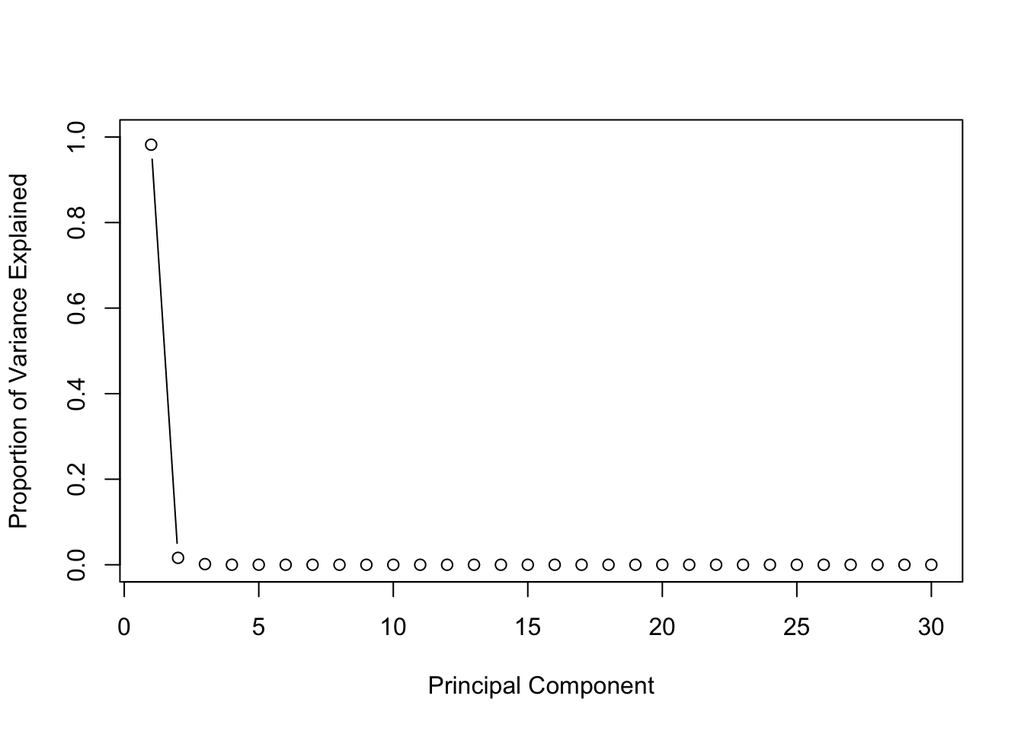

```r
# Plot variance explained for each principal component
plot(pve_cov, xlab = "Principal Component",
     ylab = "Proportion of Variance Explained",
     ylim = c(0, 1), type = "b")
```

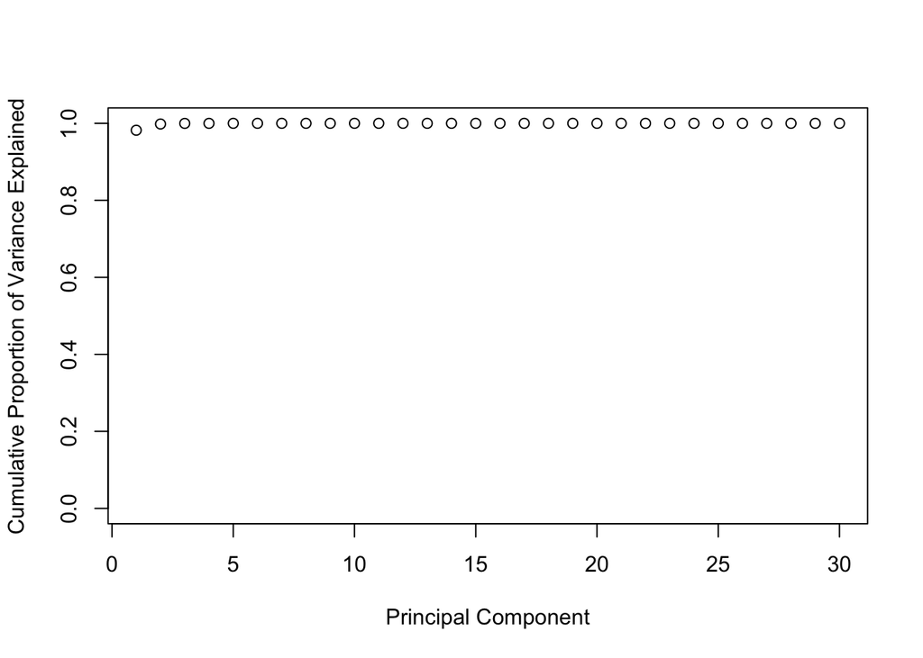

```r
# Plot cumulative proportion of variance explained
plot(cumsum(pve_cov), xlab = "Principal Component",
     ylab = "Cumulative Proportion of Variance Explained",
     ylim = c(0, 1), type = "b")
```

## Step 5: Recasting the data along the principal components axes

By using the selected feature vector we can finally reorient the data using the axes from the principal components.

```r
#Visualize using a Scree Plot

# Set up 1 x 2 plotting grid
par(mfrow = c(1, 2))

# Calculate variability of each component
pr.var <- wdbc.pr$sdev ^ 2

# Assign names to the columns to be consistent with princomp.
# This is done for reporting purposes.
names(pr.var) <- names(pr.cvar)

# Variance explained by each principal component: pve
pve <- pr.var/sum(pr.var)

# Assign names to the columns as it is not done by default.
# This is done to be consistent with princomp.
names(pve) <- names(pve_cov)

round(pr.var, 2) #Eigen values
```

```
##  Comp.1  Comp.2  Comp.3  Comp.4  Comp.5  Comp.6  Comp.7  Comp.8  Comp.9 Comp.10
##   13.27    5.71    2.82    1.98    1.66    1.21    0.67    0.48    0.42    0.35
## Comp.11 Comp.12 Comp.13 Comp.14 Comp.15 Comp.16 Comp.17 Comp.18 Comp.19 Comp.20
##    0.29    0.26    0.24    0.16    0.09    0.08    0.06    0.05    0.05    0.03
## Comp.21 Comp.22 Comp.23 Comp.24 Comp.25 Comp.26 Comp.27 Comp.28 Comp.29 Comp.30
##    0.03    0.03    0.02    0.02    0.02    0.01    0.01    0.00    0.00    0.00
```

```r
round(pve, 2) #Percent variance explained
```

```
##  Comp.1  Comp.2  Comp.3  Comp.4  Comp.5  Comp.6  Comp.7  Comp.8  Comp.9 Comp.10
##    0.44    0.19    0.09    0.07    0.06    0.04    0.02    0.02    0.01    0.01
## Comp.11 Comp.12 Comp.13 Comp.14 Comp.15 Comp.16 Comp.17 Comp.18 Comp.19 Comp.20
##    0.01    0.01    0.01    0.01    0.00    0.00    0.00    0.00    0.00    0.00
## Comp.21 Comp.22 Comp.23 Comp.24 Comp.25 Comp.26 Comp.27 Comp.28 Comp.29 Comp.30
##    0.00    0.00    0.00    0.00    0.00    0.00    0.00    0.00    0.00    0.00
```

```r
round(cumsum(pve), 2) # Cummulative percent explained
```

```
##  Comp.1  Comp.2  Comp.3  Comp.4  Comp.5  Comp.6  Comp.7  Comp.8  Comp.9 Comp.10
##    0.44    0.63    0.73    0.79    0.85    0.89    0.91    0.93    0.94    0.95
## Comp.11 Comp.12 Comp.13 Comp.14 Comp.15 Comp.16 Comp.17 Comp.18 Comp.19 Comp.20
##    0.96    0.97    0.98    0.98    0.99    0.99    0.99    0.99    0.99    1.00
## Comp.21 Comp.22 Comp.23 Comp.24 Comp.25 Comp.26 Comp.27 Comp.28 Comp.29 Comp.30
##    1.00    1.00    1.00    1.00    1.00    1.00    1.00    1.00    1.00    1.00
```

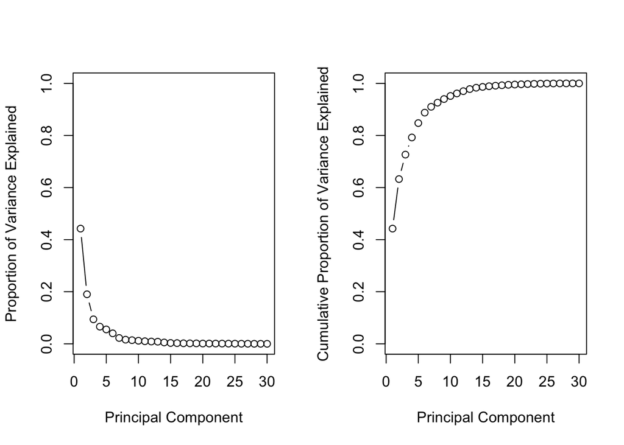

```r
plot(pve, xlab = "Principal Component",
     ylab = "Proportion of Variance Explained",
     ylim = c(0, 1), type = "b")

# Plot cumulative proportion of variance explained
plot(cumsum(pve), xlab = "Principal Component",
     ylab = "Cumulative Proportion of Variance Explained",
     ylim = c(0, 1), type = "b")
```

```r
#Majority of the variation is explained by the first six PC’s and the eigen values associated with the first 6 PC’s are greater than 1. This is the selection criteria we will use for the rest of the PCA.
```

## PCA in less steps

```r
wbg.pca<-prcomp(wbg, center=TRUE, scale =TRUE)

wdbc.pca<-princomp(wdbc.data, center=TRUE, scale =TRUE)
wbg.pca
```

```
## Standard deviations (1, .., p=13):
##  [1] 2.17105943 1.63781730 1.17162926 1.10492374 1.00608224 0.83074079
##  [7] 0.71444465 0.65761504 0.52192250 0.24515367 0.14647325 0.09784617
## [13] 0.04161354
##
## Rotation (n x k) = (13 x 13):
##                                PC1         PC2         PC3         PC4
## LAT                     0.20502759 -0.45993151 -0.14883206 -0.12248527
## LON                    -0.10401828 -0.01594743 -0.73055743 -0.12278093
## ALTITUDE               -0.42758109  0.11298066  0.06009671  0.06273283
## RECORD.LENGTH           0.04067894 -0.03117858 -0.14533064  0.02692803
## MEAN.ANNUAL.AIR.TEMP    0.42393848  0.13805683  0.16674865  0.11650671
## MEAN.MONTHLY.MAX.TEMP   0.36582631  0.34459688  0.05712672  0.02664235
## MEAN.MONTHLY.MIN.TEMP   0.39245789 -0.08381029  0.25490700  0.25722911
## MEAN.ANNUAL.RAINFALL   -0.36811710  0.07858829  0.34376283  0.17309381
## MEAN.ANNUAL.SUNSHINE   -0.01921069  0.01176214 -0.30245296  0.69344905
## MEAN.ANNUAL.WIND.SPEED -0.05562375 -0.50547309 -0.01001127  0.21256393
## MEAN.RANGE.AIR.TEMP     0.05251610  0.53325124 -0.19910592 -0.24175182
## MEAN.CLOUD.COVER       -0.11003092 -0.23633688  0.23935224 -0.48180107
## MAX.RAINFALL           -0.37583188  0.16616730  0.12912218  0.19549566
##                                 PC5         PC6         PC7          PC8
## LAT                     0.133063365 -0.10411263  0.02133133  0.572509801
## LON                     0.171401184 -0.09549211 -0.52716324 -0.092655671
## ALTITUDE               -0.064344175  0.02243782  0.14030639 -0.344128929
## RECORD.LENGTH          -0.949843888 -0.23719866 -0.09034671  0.089655470
## MEAN.ANNUAL.AIR.TEMP    0.022723368  0.01022428 -0.26359329 -0.097581198
## MEAN.MONTHLY.MAX.TEMP  -0.002408029  0.05550861 -0.22721810 -0.081824847
## MEAN.MONTHLY.MIN.TEMP   0.016759352 -0.05625575 -0.32164108 -0.093739569
## MEAN.ANNUAL.RAINFALL    0.034749214 -0.13704659 -0.23410563  0.377119294
## MEAN.ANNUAL.SUNSHINE   -0.077133928  0.61282883  0.08250589  0.194513602
## MEAN.ANNUAL.WIND.SPEED  0.002800018 -0.06962849 -0.12796631 -0.554985004
## MEAN.RANGE.AIR.TEMP    -0.024823742  0.13396876  0.04443454 -0.003703994
## MEAN.CLOUD.COVER       -0.186404458  0.69185025 -0.35748300 -0.004475645
## MAX.RAINFALL            0.056932708 -0.14536586 -0.51134767  0.155188656
##                                 PC9         PC10         PC11         PC12
## LAT                     0.204395502 -0.084580122 -0.550912309  0.004442119
## LON                    -0.203936888  0.268528888  0.025347358  0.028508656
## ALTITUDE               -0.234686588  0.127321765 -0.761672693  0.050518927
## RECORD.LENGTH           0.006676567  0.011437052 -0.019642642  0.017161328
## MEAN.ANNUAL.AIR.TEMP   -0.006669925  0.039153700 -0.138682827  0.811801072
## MEAN.MONTHLY.MAX.TEMP   0.191809126  0.086969234 -0.231561151 -0.407190241
## MEAN.MONTHLY.MIN.TEMP  -0.290881473  0.098544221 -0.124395317 -0.410346533
## MEAN.ANNUAL.RAINFALL    0.246445156  0.652262806  0.074819635  0.036946986
## MEAN.ANNUAL.SUNSHINE    0.026626053  0.003346446 -0.009076770  0.013742342
## MEAN.ANNUAL.WIND.SPEED  0.605345930  0.009253004  0.011956023 -0.014291312
## MEAN.RANGE.AIR.TEMP     0.553793589 -0.012989741 -0.137749087 -0.035443392
## MEAN.CLOUD.COVER       -0.033646560  0.011807013 -0.009814602 -0.005053573
## MAX.RAINFALL            0.065994746 -0.678039420 -0.045824409 -0.008470810
##                                 PC13
## LAT                     0.0070603226
## LON                    -0.0002249761
## ALTITUDE                0.0110655936
## RECORD.LENGTH          -0.0020078827
## MEAN.ANNUAL.AIR.TEMP   -0.0195381409
## MEAN.MONTHLY.MAX.TEMP  -0.6467314720
## MEAN.MONTHLY.MIN.TEMP   0.5603044697
## MEAN.ANNUAL.RAINFALL    0.0045395157
## MEAN.ANNUAL.SUNSHINE   -0.0005152601
## MEAN.ANNUAL.WIND.SPEED  0.0017637039
## MEAN.RANGE.AIR.TEMP     0.5168742141
## MEAN.CLOUD.COVER       -0.0023303971
## MAX.RAINFALL           -0.0071288448
```

```r
wdbc.pca
```

```
## Call:
## princomp(x = wdbc.data, center = TRUE, scale = TRUE)
##
## Standard deviations:
##       Comp.1       Comp.2       Comp.3       Comp.4       Comp.5       Comp.6
## 6.653817e+02 8.541786e+01 2.651082e+01 7.391720e+00 6.285379e+00 1.723376e+00
##       Comp.7       Comp.8       Comp.9      Comp.10      Comp.11      Comp.12
## 1.341902e+00 6.094794e-01 3.939371e-01 2.896455e-01 1.776972e-01 8.644681e-02
##      Comp.13      Comp.14      Comp.15      Comp.16      Comp.17      Comp.18
## 5.622228e-02 4.648825e-02 3.642125e-02 2.526125e-02 1.935774e-02 1.528887e-02
##      Comp.19      Comp.20      Comp.21      Comp.22      Comp.23      Comp.24
## 1.357492e-02 1.271995e-02 8.801581e-03 7.579317e-03 5.909075e-03 5.305210e-03
##      Comp.25      Comp.26      Comp.27      Comp.28      Comp.29      Comp.30
## 3.978787e-03 3.530384e-03 1.917828e-03 1.675896e-03 1.415907e-03 8.352584e-04
##
##  30  variables and  568 observations.
```

## Visualizing PCA

Let’s install ggbiplot to explore some ways in which we can visualize PCAs.

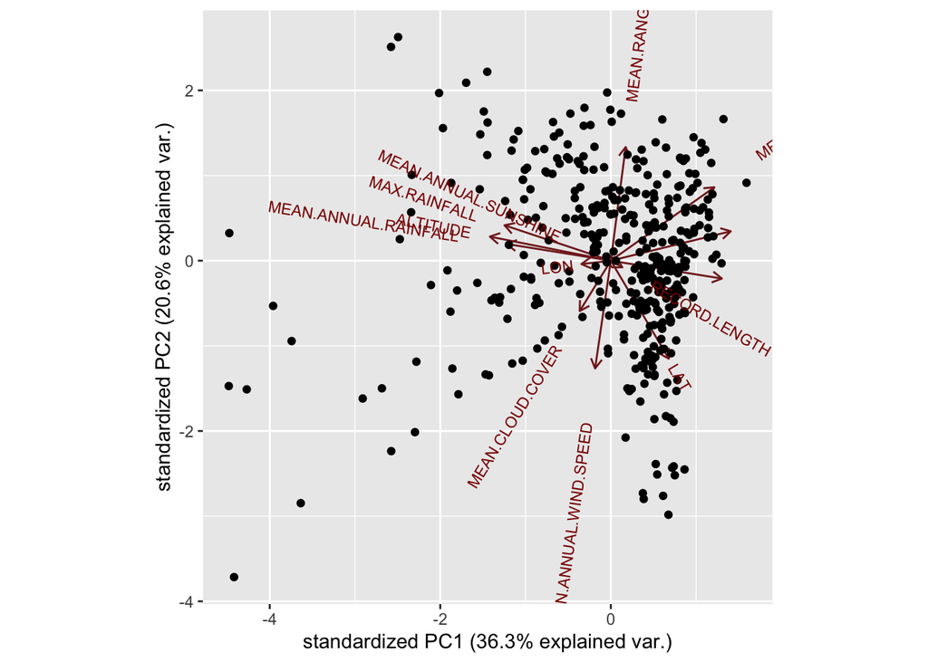

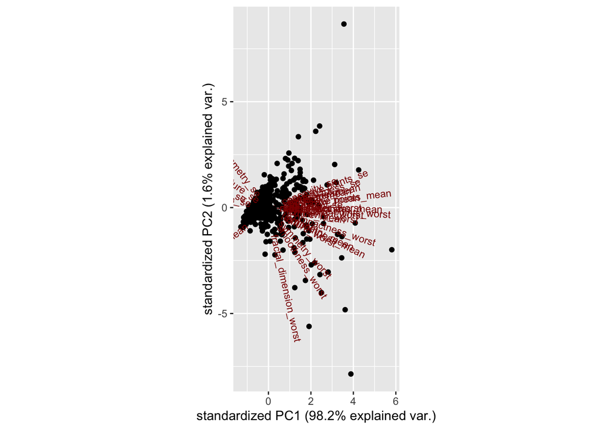

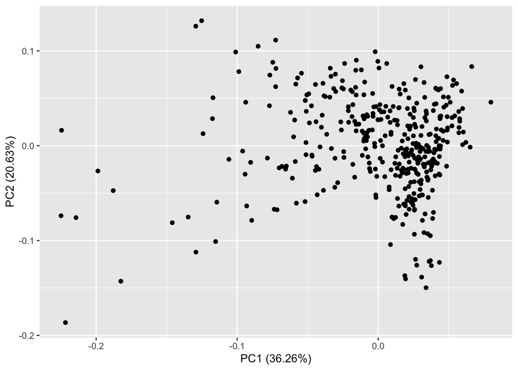

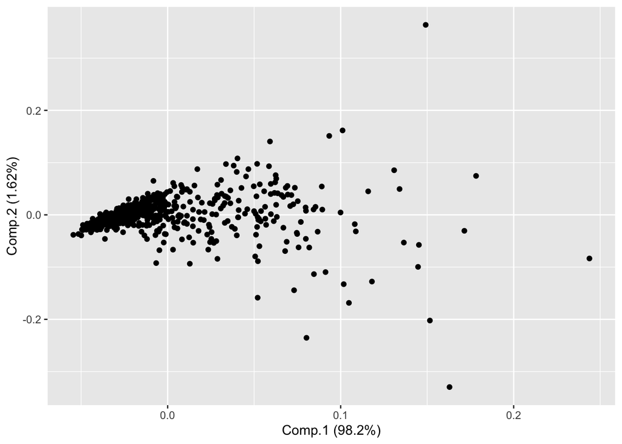